# Biostatistical Computing, PHC 6068

multi-variate optimization

Zhiguang Huo (Caleb)

Monday Nov 27, 2017

# Outline

- Recap of Univariate Optimization
- Multi-variate Optimization
  - Gradient decent
  - Newton’s method
  - coordinate decent
- Optimization problem with constraint
- Multi-variate Optimization using R package

# Univariate Gradient decent

- Consider an unconstrained minimization of $f$, we want to find $\beta^*$ such that
  $$f(\beta^*) = \min_{\beta\in \mathbb{R}} f(\beta)$$
- Another way to formulate the problem is to find $\beta^*$ such that
  $$\beta^* = \arg_{\beta\in \mathbb{R}} \min f(\beta)$$

**Gradient decent**: choose initial $\beta^{(0)} \in \mathbb{R}$, repeat:
$$\beta^{(k)} = \beta^{(k - 1)} - t\times f'(\beta^{(k - 1)}), k = 1,2,3,\ldots$$

- Until $|\beta^{(k)} - \beta^{(k - 1)}| < \varepsilon$, (e.g. $\varepsilon = 10^{-6}$).
- $f'(\beta^{(k - 1)})$ is the gradient (derivative of $f$) evaluated at $\beta^{(k - 1)}$.
- $t$ is a step size for gradient decent procedure.

# Interpretation

- At each iteration $k$, consider Taylor expansion at $\beta^{(k - 1)}$:
  $$f(y) = f(\beta^{(k - 1)}) + f'(\beta^{(k - 1)}) \times (y - \beta^{(k - 1)}) + \frac{1}{2} f''(\beta^{(k - 1)}) (y - \beta^{(k - 1)})^2 + \ldots$$
- Quadratic approximation:
  - Replacing $f''(\beta^{(k - 1)})$ with $\frac{1}{t}$
  - Ignore higher order terms

$$f(y) \approx f(\beta^{(k - 1)}) + f'(\beta^{(k - 1)}) \times (y - \beta^{(k - 1)}) + \frac{1}{2t} (y - \beta^{(k - 1)})^2$$

- Minimizing the quadratic approximation.
  $$\beta^{(k)} = \arg_y \min f(y)$$
  - Set $f'(\beta^{(k)}) = 0 \Leftrightarrow f'(\beta^{(k - 1)}) + \frac{1}{t} (\beta^{(k)} - \beta^{(k - 1)}) = 0 \Leftrightarrow \beta^{(k)} = \beta^{(k - 1)} - t\times f'(\beta^{(k - 1)})$
  - This is exactly the same as the gradient decent procedure.

# Visual interpretation

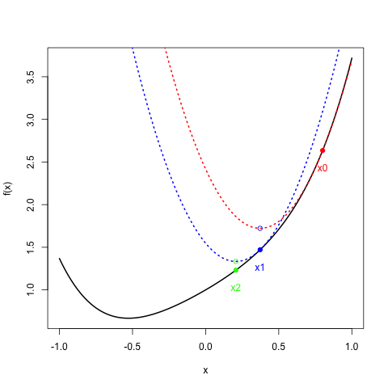

- iterate 1: $\beta^{(1)} = \beta^{(0)} - t\times f'(\beta^{(0)})$
  - quadratic approximation at $\beta_0$,
  - minimizer of the quadratic approximation is $\beta_1$
- iterate 2: $\beta^{(2)} = \beta^{(1)} - t\times f'(\beta^{(1)})$
  - quadratic approximation at $\beta_1$,
  - minimizer of the quadratic approximation is $\beta_2$
- …

# Newton’s method

- For unconstrained, smooth univariate convex optimization
  $$\min f(\beta)$$
  where $f$ is convex, twice differentiable, $\beta \in \mathbb{R}$, $f \in \mathbb{R}$. For **gradient descent**, start with initial value $\beta^{(0)}$ and repeat the following $(k = 1,2,3,\ldots)$ until converge
  $$\beta^{(k)} = \beta^{(k - 1)} - t_k f'(\beta^{(k - 1)})$$
- For **Newton’s method**, start with initial value $\beta^{(0)}$ and repeat the following $(k = 1,2,3,\ldots)$ until converge
  $$\beta^{(k)} = \beta^{(k - 1)} - (f''(\beta^{(k - 1)}))^{-1} f'(\beta^{(k - 1)})$$
  Where $f''(\beta^{(k - 1)})$ is the second derivative of $f$ at $\beta^{(k - 1)}$. It is also referred as Hessian matrix for higher dimension (e.g. $\beta \in \mathbb{R}^p$)

# Newton’s method interpretation

- For gradient decent step at $\beta$, we minimize the quadratic approximation
  $$f(y) \approx f(\beta) + f'(\beta)(y - \beta) + \frac{1}{2t}(y - \beta)^2$$
  over $y$, which yield the update $\beta^{(k)} = \beta^{(k - 1)} - tf'(\beta^{(k-1)})$
- Newton’s method uses a better quadratic approximation:
  $$f(y) \approx f(\beta) + f'(\beta)(y - \beta) + \frac{1}{2}f''(\beta)(y - \beta)^2$$
  minimizing over $y$ yield $\beta^{(k)} = \beta^{(k - 1)} - (f''(\beta^{(k-1)}))^{-1}f'(\beta^{(k-1)})$

# New problem?

- What if $\beta$ is not a scalar but instead a vector (i.e. $\beta \in \mathbb{R}^p$)?
- Will gradient decent still work?
  - Yes
- How to calculate the gradient (derivative) for multivariate case?
- Will Newton’s method still work?
  - Yes
- How to calculate the Hessian matrix for multivariate case?

# Gradient in multivariate case

- $\beta = (\beta_1, \beta_2, \ldots, \beta_p)^\top \in \mathbb{R}^p$ is a $p$-dimensional column vector
- $f(\beta) \in \mathbb{R}$ is a function which map $\mathbb{R}^p \rightarrow \mathbb{R}$
- Suppose $f(\beta)$ is differentiable with respect to $\beta$.

Then
$$\nabla_\beta f(\beta) = \frac{\partial f(\beta)}{\partial \beta}
= (\frac{\partial f(\beta)}{\partial \beta_1}, \frac{\partial f(\beta)}{\partial \beta_2}, \ldots,
\frac{\partial f(\beta)}{\partial \beta_p})^\top \in \mathbb{R}^p$$

- Example
  $$f(x,y) = 4x^2 + y^2 + 2xy - x - y$$
  - $\frac{\partial f}{\partial x} = 8x + 2y - 1$
  - $\frac{\partial f}{\partial y} = 2y +2x - 1$
  - $\nabla f = (\frac{\partial f}{\partial x}, \frac{\partial f}{\partial y})^\top = \binom{8x + 2y - 1}{2y +2x - 1} \in \mathbb{R}^2$

# Visualization of the example function

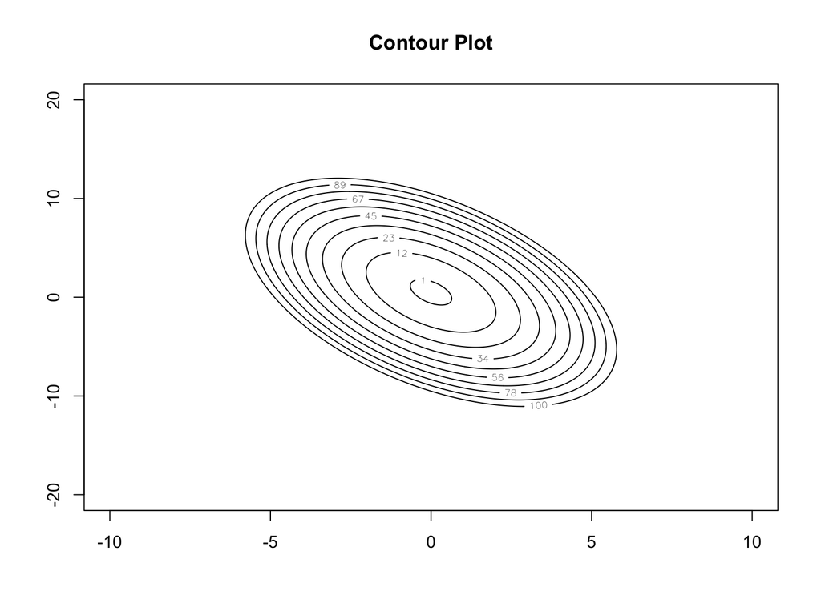

```r
f <- function(x,y){
  4 * x^2 + y^2 + 2 * x * y - x - y
}


x <- y <- seq(-20, 20, len=1000)
z <- outer(x, y, f)
# Contour plots
contour(x,y,z, xlim = c(-10,10), ylim = c(-20,20), nlevels = 10, levels = seq(1,100,length.out = 10), main="Contour Plot")
```

# Hessian in multivariate case

- $\beta = (\beta_1, \beta_2, \ldots, \beta_p)^\top \in \mathbb{R}^p$ is a $p$-dimensional column vector
- $f(\beta) \in \mathbb{R}$ is a function which map $\mathbb{R}^p \rightarrow \mathbb{R}$
- Suppose $f(\beta)$ is twice differentiable with respect to $\beta$.

Then
$$\nabla_\beta f(\beta) = \frac{\partial f(\beta)}{\partial \beta}
= (\frac{\partial f(\beta)}{\partial \beta_1}, \frac{\partial f(\beta)}{\partial \beta_2}, \ldots,
\frac{\partial f(\beta)}{\partial \beta_p})^\top \in \mathbb{R}^p$$

$$\Delta_\beta f(\beta) = \nabla^2_\beta f(\beta) = \nabla_\beta\frac{\partial f(\beta)}{\partial \beta}
= (\nabla_\beta \frac{\partial f(\beta)}{\partial \beta_1}, \nabla_\beta \frac{\partial f(\beta)}{\partial \beta_2}, \ldots,
\nabla_\beta \frac{\partial f(\beta)}{\partial \beta_p})^\top$$

$$\Delta_\beta f(\beta)
=
\begin{pmatrix}
\frac{\partial^2 f(\beta)}{\partial \beta_1^2} & \frac{\partial^2 f(\beta)}{\partial \beta_1 \partial \beta_2} & \ldots & \frac{\partial^2 f(\beta)}{\partial \beta_1 \partial\beta_p}\\
\frac{\partial^2 f(\beta)}{\partial \beta_2 \partial \beta_1 } & \frac{\partial^2 f(\beta)}{\partial \beta_2^2} & \ldots & \frac{\partial^2 f(\beta)}{\partial \beta_2 \partial \beta_p} \\
\ldots &\ldots &\ldots &\ldots\\
\frac{\partial^2 f(\beta)}{\partial \beta_p \partial \beta_1} & \frac{\partial^2 f(\beta)}{\partial \beta_p \partial \beta_2} & \ldots & \frac{\partial^2 f(\beta)}{\partial\beta_p^2}
\end{pmatrix}$$

# Hessian in multivariate case example

$$f(x,y) = 4x^2 + y^2 + 2xy - x - y$$

- Gradient
  - $\frac{\partial f}{\partial x} = 8x + 2y - 1$
  - $\frac{\partial f}{\partial y} = 2y +2x - 1$

$$\nabla f = (\frac{\partial f}{\partial x}, \frac{\partial f}{\partial y})^\top =
\binom{8x + 2y - 1}{2y +2x - 1} \in \mathbb{R}^2$$

- Hessian
  - $\frac{\partial^2 f}{\partial x^2} = 8$
  - $\frac{\partial^2 f}{\partial y^2} = 2$
  - $\frac{\partial^2 f}{\partial x \partial y} = 2$

$$\Delta f = \begin{pmatrix}
8 & 2 \\
2 & 2
\end{pmatrix}
\in \mathbb{R}^{2\times 2}$$

# Gradient decent for multivariate case

**Gradient decent**: choose initial $\beta^{(0)} \in \mathbb{R}^p$, repeat:
$$\beta^{(k)} = \beta^{(k - 1)} - t\times \nabla_\beta f(\beta^{(k - 1)}), k = 1,2,3,\ldots$$

- Until $\frac{\|\beta^{(k)} - \beta^{(k - 1)}\|_2}{\|\beta^{(k)} + \beta^{(k - 1)}\|_2} < \varepsilon$, (e.g. $\varepsilon = 10^{-6}$).
- $\nabla_\beta f(\beta^{(k - 1)})$ is the gradient (derivative of $f$) evaluated at $\beta^{(k - 1)}$.
- $t$ is a step size for gradient decent procedure.

# Gradient decent on our motivating example

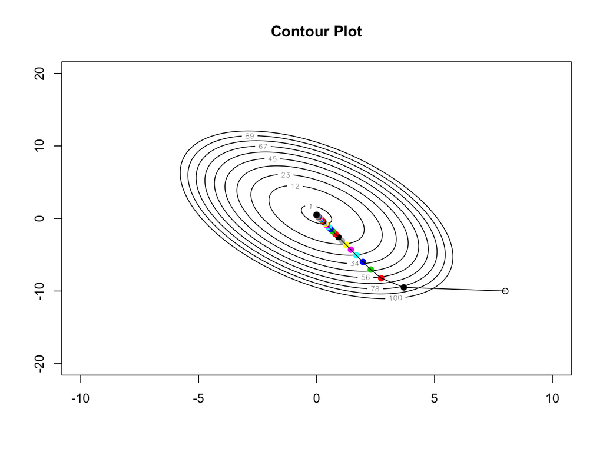

```r
f <- function(x,y){
  4 * x^2 + y^2 + 2 * x * y - x - y
}

g <- function(x,y){
  c(8*x + 2*y - 1, 2*y +2*x - 1)
}

x <- y <- seq(-20, 20, len=1000)
z <- outer(x, y, f)
# Contour plots
contour(x,y,z, xlim = c(-10,10), ylim = c(-20,20), nlevels = 10, levels = seq(1,100,length.out = 10), main="Contour Plot")


x <- x0 <- 8; x_old <- 0;
y <- y0 <- -10; y_old <- 0;
curXY <- c(x,y)
preXY <- c(x_old, y_old)
t <- 0.1; k <- 0; error <- 1e-6
trace <- list(curXY)
points(x0,y0, col=1, pch=1)

l2n <- function(avec){
  sqrt(sum(avec^2))
}
diffChange <- function(avec, bvec){
  deltaVec <- avec - bvec
  sumVec <- avec + bvec
  l2n(deltaVec)/l2n(sumVec)
}

while(diffChange(curXY, preXY) > error){
  k <- k + 1
  preXY <- curXY
  curXY <- preXY - t*g(preXY[1], preXY[2])
  trace <- c(trace, list(curXY)) ## collecting results
  points(curXY[1], curXY[2], col=k, pch=19)
  segments(curXY[1], curXY[2], preXY[1], preXY[2])
}
```

```r
print(k)
```

```
## [1] 97
```

# Divergence of Gradient decent

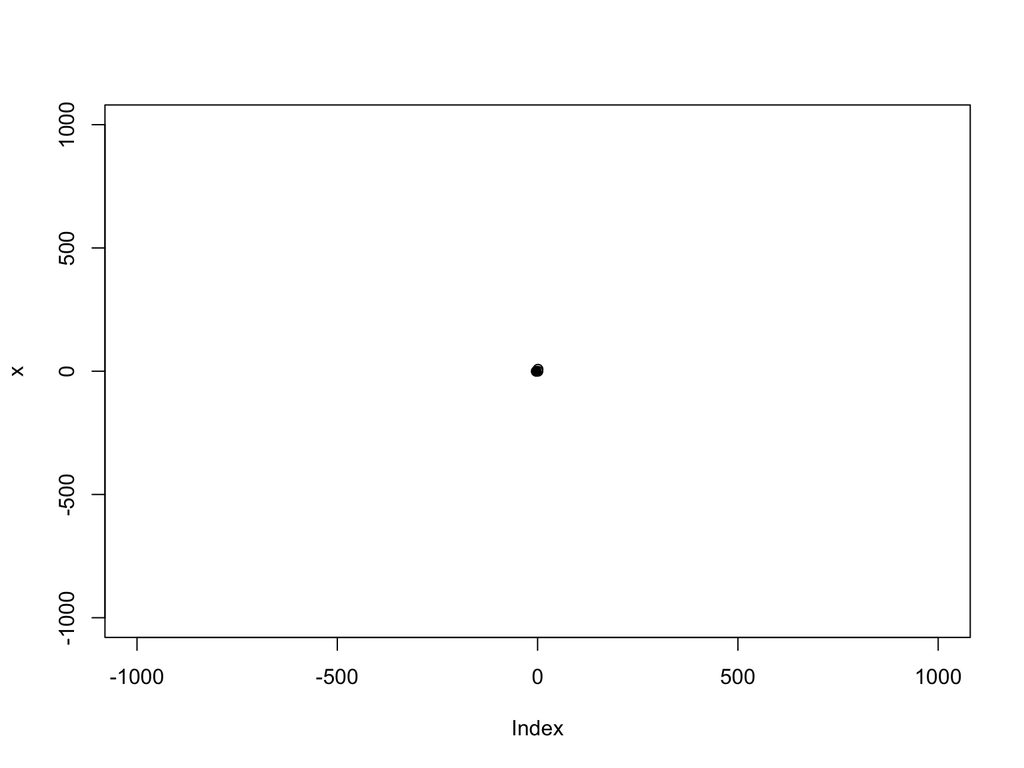

```r
f <- function(x,y){
  4 * x^2 + y^2 + 2 * x * y - x - y
}

g <- function(x,y){
  c(8*x + 2*y - 1, 2*y +2*x - 1)
}

B <- 1000
plot(x,xlim=c(-B,B), ylim=c(-B,B))
#contour(x,y,z, xlim = c(-100,100), ylim = c(-200,200), nlevels = 10, levels = seq(1,10000,length.out = 10), main="Contour Plot")


x <- x0 <- 0.8; x_old <- 0;
y <- y0 <- -0.10; y_old <- 0;
curXY <- c(x,y)
preXY <- c(x_old, y_old)
t <- 0.8; k <- 0; error <- 1e-6
trace <- list(curXY)
points(x0,y0, col=1, pch=1)

l2n <- function(avec){
  sqrt(sum(avec^2))
}
diffChange <- function(avec, bvec){
  deltaVec <- avec - bvec
  sumVec <- avec + bvec
  l2n(deltaVec)/l2n(sumVec)
}

## repeat the following chunk of code to see divergence of gradient decent
k <- k + 1
preXY <- curXY
curXY <- preXY - t*g(preXY[1], preXY[2])
points(curXY[1], curXY[2], col=k, pch=19)
segments(curXY[1], curXY[2], preXY[1], preXY[2])
```

# How to select step size $t$, backtracking line search

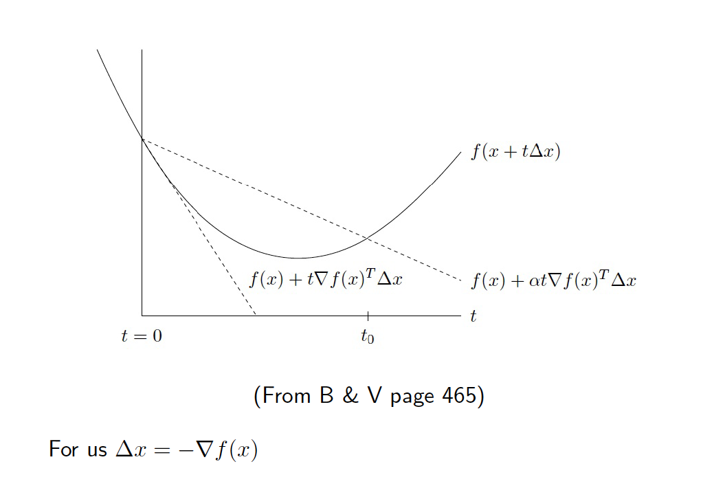

# How to select step size $t$, backtracking line search

- Purpose, we want to select $t$ such that $f(\beta - t\times \nabla f(\beta)) < f(\beta)$
  - $\beta$ is current position.
  - $t$ is step size.
- A sufficient condition:
  - $f(\beta - t\times \nabla f(\beta)) < f(\beta) - \alpha t \times \|(\nabla f(\beta)\|_2^2$
- Algorithm:
  - Fix parameter $0 < \gamma < 1$ and $0 < \alpha \le 1/2$
  - At each gradient decent iteration, start with $t=1$, while
    $$f(\beta - t\times \nabla f(\beta)) > f(\beta) - \alpha t \times \|(\nabla f(\beta)\|_2^2$$
    Update $t = \gamma t$

# Implementation of back-tracking for gradient decent

- Minimize $f(x,y) = 4x^2 + y^2 + 2xy - x - y$
- gradient $\nabla f = \binom{8x + 2y - 1}{2y +2x - 1}$
- Initial point $x_0 = 8$; $y_0 = -10$
- initial step size $t_0 = 1$, $\alpha = 1/3$, $\gamma = 1/2$
  - At each step, start with $t = t_0$,
  - if $f(x - tg(x)) > f(x) - \alpha t \|g(x)\|_2^2$, set $t = \gamma t$
  - otherwise, use $t$ as step size

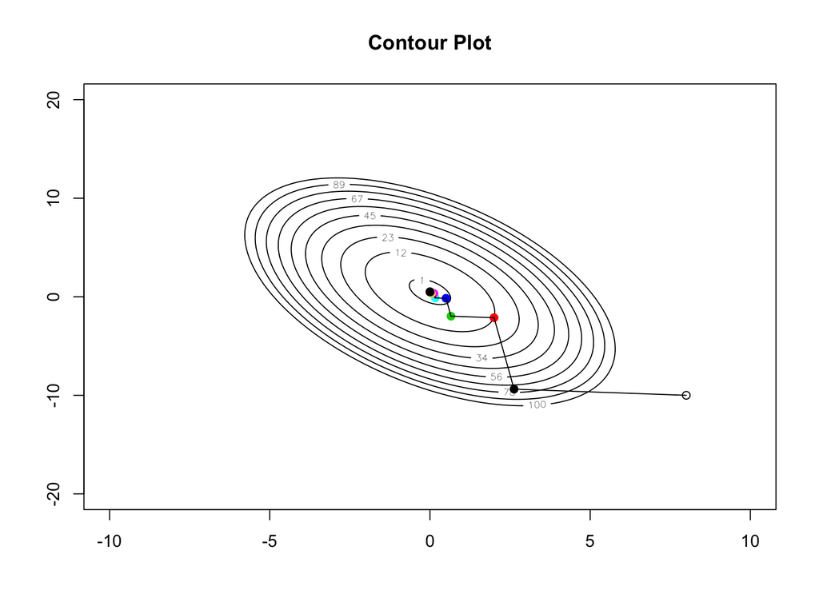

```r
f0 <- function(x,y){
  4 * x^2 + y^2 + 2 * x * y - x - y
}

f <- function(avec){
  x <- avec[1]
  y <- avec[2]
  4 * x^2 + y^2 + 2 * x * y - x - y
}

g <- function(avec){
  x <- avec[1]
  y <- avec[2]
  c(8*x + 2*y - 1, 2*y +2*x - 1)
}

x <- y <- seq(-20, 20, len=1000)
z <- outer(x, y, f0)
# Contour plots
contour(x,y,z, xlim = c(-10,10), ylim = c(-20,20), nlevels = 10, levels = seq(1,100,length.out = 10), main="Contour Plot")


x <- x0 <- 8; x_old <- 0;
y <- y0 <- -10; y_old <- 0;
curXY <- c(x,y)
preXY <- c(x_old, y_old)
t0 <- 1; k <- 0; error <- 1e-6
alpha = 1/3
beta = 1/2
trace <- list(curXY)
points(x0,y0, col=1, pch=1)

l2n <- function(avec){
  sqrt(sum(avec^2))
}
diffChange <- function(avec, bvec){
  deltaVec <- avec - bvec
  sumVec <- avec + bvec
  l2n(deltaVec)/l2n(sumVec)
}

while(diffChange(curXY, preXY) > error){
  k <- k + 1
  preXY <- curXY

  ## backtracking
  t <- t0
  while(f(preXY - t*g(preXY)) > f(preXY) - alpha * t * l2n(g(preXY))^2){
    t <- t * beta
  }

  curXY <- preXY - t*g(preXY)
  trace <- c(trace, list(curXY)) ## collecting results
  points(curXY[1], curXY[2], col=k, pch=19)
  segments(curXY[1], curXY[2], preXY[1], preXY[2])

}
```

```r
print(k)
```

```
## [1] 25
```

# Exercise, solve for logistic regression

```r
library(ElemStatLearn)
glm_binomial_logit <- glm(svi ~ lcavol, data = prostate,  family = binomial())
summary(glm_binomial_logit)
```

```
##
## Call:
## glm(formula = svi ~ lcavol, family = binomial(), data = prostate)
##
## Deviance Residuals:
##      Min        1Q    Median        3Q       Max
## -1.79924  -0.48354  -0.21025  -0.04274   2.32135
##
## Coefficients:
##             Estimate Std. Error z value Pr(>|z|)
## (Intercept)  -5.0296     1.0429  -4.823 1.42e-06 ***
## lcavol        1.9798     0.4543   4.358 1.31e-05 ***
## ---
## Signif. codes:  0 '***' 0.001 '**' 0.01 '*' 0.05 '.' 0.1 ' ' 1
##
## (Dispersion parameter for binomial family taken to be 1)
##
##     Null deviance: 101.35  on 96  degrees of freedom
## Residual deviance:  64.14  on 95  degrees of freedom
## AIC: 68.14
##
## Number of Fisher Scoring iterations: 6
```

- Optimize $\beta_1$, the coefficient for lcavol and the intercept $\beta_0$ simultaneously using gradient decent method.

# Newton’s method for multivariate case

- For unconstrained, smooth univariate convex optimization
  $$\min f(\beta)$$
  where $f$ is convex, twice differentiable, $\beta \in \mathbb{R}^p$, $f \in \mathbb{R}$. For **gradient descent**, start with initial value $\beta^{(0)}$ and repeat the following $(k = 1,2,3,\ldots)$ until converge
  $$\beta^{(k)} = \beta^{(k - 1)} - t_k \nabla f(\beta^{(k - 1)})$$
- For **Newton’s method**, start with initial value $\beta^{(0)}$ and repeat the following $(k = 1,2,3,\ldots)$ until converge
  $$\beta^{(k)} = \beta^{(k - 1)} - (\Delta f(\beta^{(k - 1)}))^{-1} \nabla f(\beta^{(k - 1)})$$
  Where $\Delta f(\beta^{(k - 1)}) \in \mathbb{R}^{p\times p}$ is the Hessian matrix of $f$ at $\beta^{(k - 1)}$.

# Implement multivariate Newton’s method

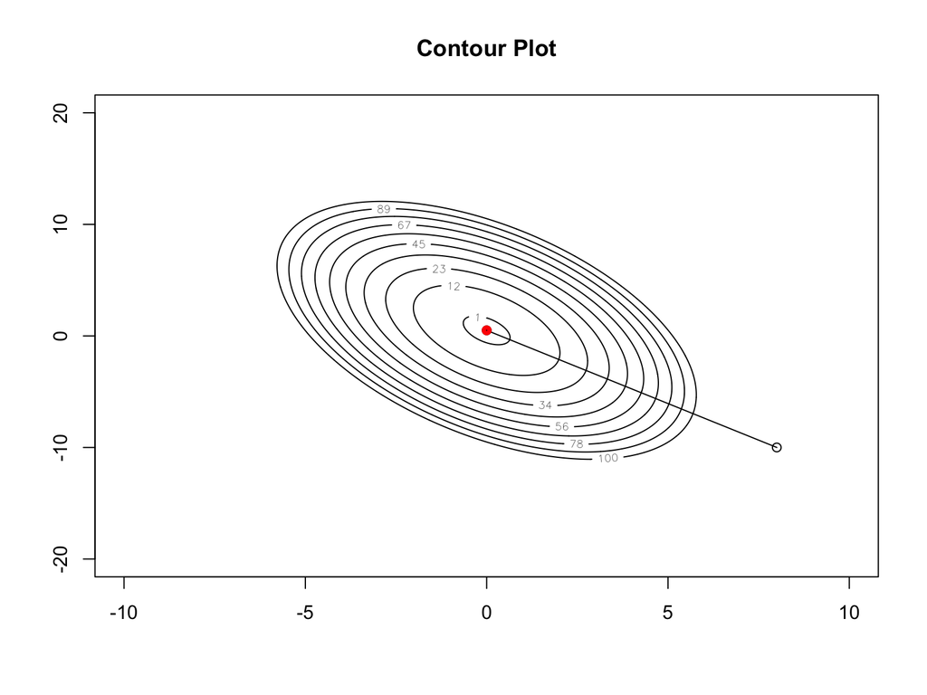

```r
f0 <- function(x,y){
  4 * x^2 + y^2 + 2 * x * y - x - y
}

f <- function(avec){
  x <- avec[1]
  y <- avec[2]
  4 * x^2 + y^2 + 2 * x * y - x - y
}

g <- function(avec){
  x <- avec[1]
  y <- avec[2]
  c(8*x + 2*y - 1, 2*y +2*x - 1)
}

h <- function(avec){
  x <- avec[1]
  y <- avec[2]
  res <- matrix(c(8,2,2,2),2,2)  ## Hessian function
  return(res)
}

x <- y <- seq(-20, 20, len=1000)
z <- outer(x, y, f0)
# Contour plots
contour(x,y,z, xlim = c(-10,10), ylim = c(-20,20), nlevels = 10, levels = seq(1,100,length.out = 10), main="Contour Plot")


x <- x0 <- 8; x_old <- 0;
y <- y0 <- -10; y_old <- 0;
curXY <- c(x,y)
preXY <- c(x_old, y_old)
t0 <- 1; k <- 0; error <- 1e-6
trace <- list(curXY)
points(x0,y0, col=1, pch=1)

l2n <- function(avec){
  sqrt(sum(avec^2))
}
diffChange <- function(avec, bvec){
  deltaVec <- avec - bvec
  sumVec <- avec + bvec
  l2n(deltaVec)/l2n(sumVec)
}

while(diffChange(curXY, preXY) > error){
  k <- k + 1
  preXY <- curXY

  curXY <- preXY - solve(h(curXY)) %*% g(preXY)
  trace <- c(trace, list(curXY)) ## collecting results
  points(curXY[1], curXY[2], col=k, pch=19)
  segments(curXY[1], curXY[2], preXY[1], preXY[2])
}
```

```r
k ## why k is only 2?
```

```
## [1] 2
```

# Exercise

$$f(x,y) = \exp(xy) + y^2 + x^4$$

What are the x and y such that $f(x,y)$ is minimized?

- Use Newton’s method to solve this problem

# Divergence in Newton’s method

- Here’s an example of Newton’s method for root finding, generated from the polynomial $z^4 - 1$, so that the four roots of the function are at 1, -1, i and -i.

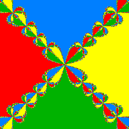

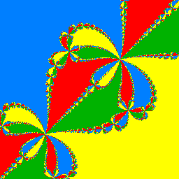

Note: same color denotes the region where will lead to the same root. Reference: https://www.chiark.greenend.org.uk/~sgtatham/newton/

- Here’s another example, generated from the polynomial $(z^2 + 1)(z^2 - 2.3^2)$,

[figure not shown]

# Backtracking line search for Newton’s method

- Usually pure Newton’s method works very well (do not necessary need to use backtracking)
- We have seen pure Newton’s method, which need not to decent at all iterations.
- In practice, we can use Newton’s method with backtracking search, which repeats
  $$\beta^{(k)} = \beta^{(k - 1)} - t (\Delta f(\beta^{(k - 1)}))^{-1} \nabla f(\beta^{(k - 1)})$$
- Note that the pure Newton’s method uses $t = 1$
- Algorithm:
  - Fix parameter $0 < \gamma < 1$ and $0 < \alpha \le 1/2$
  - At each Newton’s iteration $x$, start with $t=1$, while
    $$f(\beta + t \Delta \beta) > f(\beta) + \alpha t \times \nabla f(\beta)^\top \Delta \beta$$
    Update $t = \gamma t$
  - In other word (set $\Delta \beta = - (\Delta f(\beta))^{-1} \nabla f(\beta)$), while
    $$f(\beta - t \Delta f(\beta)^{-1} \nabla f(\beta))
    > f(\beta) - \alpha t (\nabla f(\beta))^\top (\Delta f(\beta))^{-1} \nabla f(\beta)$$
    Update $t = \gamma t$

# Exercise, solve for logistic regression

```r
library(ElemStatLearn)
glm_binomial_logit <- glm(svi ~ lcavol, data = prostate,  family = binomial())
summary(glm_binomial_logit)
```

```
##
## Call:
## glm(formula = svi ~ lcavol, family = binomial(), data = prostate)
##
## Deviance Residuals:
##      Min        1Q    Median        3Q       Max
## -1.79924  -0.48354  -0.21025  -0.04274   2.32135
##
## Coefficients:
##             Estimate Std. Error z value Pr(>|z|)
## (Intercept)  -5.0296     1.0429  -4.823 1.42e-06 ***
## lcavol        1.9798     0.4543   4.358 1.31e-05 ***
## ---
## Signif. codes:  0 '***' 0.001 '**' 0.01 '*' 0.05 '.' 0.1 ' ' 1
##
## (Dispersion parameter for binomial family taken to be 1)
##
##     Null deviance: 101.35  on 96  degrees of freedom
## Residual deviance:  64.14  on 95  degrees of freedom
## AIC: 68.14
##
## Number of Fisher Scoring iterations: 6
```

- Optimize $\beta_1$, the coefficient for lcavol and the intercept $\beta_0$ simultaneously using Newton’s method.

# Coordinate decent

- Suppose $\beta \in \mathbb{R}^P$ and $f(\beta)$ is a mapping from $\mathbb{R}^P$ to $R$.
- We can use **coordinate descent** to find a minimizer.
- Start with an initial guess $\beta^{(0)} = (\beta^{(0)}_1, \beta^{(0)}_2, \ldots, \beta^{(0)}_p)^\top$ and repeat the following:
  - $\beta_1^{(k)} = \arg \min_{\beta_1} f(\beta_1, \beta_2^{(k-1)}, \beta_3^{(k-1)}, \ldots, \beta_p^{(k-1)})$
  - $\beta_2^{(k)} = \arg \min_{\beta_2} f(\beta_1^{(k)}, \beta_2, \beta_3^{(k-1)}, \ldots, \beta_p^{(k-1)})$
  - $\beta_3^{(k)} = \arg \min_{\beta_3} f(\beta_1^{(k)}, \beta_2^{(k)}, \beta_3, \ldots, \beta_p^{(k-1)})$
  - $\ldots$
  - $\beta_p^{(k)} = \arg \min_{\beta_p} f(\beta_1^{(k)}, \beta_2^{(k)}, \beta_3^{(k)}, \ldots, \beta_p)$
- Continue with $k=1,2,3,\ldots$ until converge.
  - Note that after $\beta_j^{(k)}$ has been updated, we use the new value for future update.

# Example on linear regression

- Consider linear regression problem:

$$\min_{\beta \in \mathbb{R}^p} f(\beta) = \min_{\beta \in \mathbb{R}^p} \frac{1}{2} \|y - X\beta\|_2^2$$
where $y \in \mathbb{R}^n$ and $X \in \mathbb{R}^{n \times p}$ with columns $X_1$ (intercept), $X_2$, $\ldots$, $X_p$.

- Minimizing over $\beta_j$ while fixing all $\beta_i$, $i \ne j$:
  $$0 = \frac{\partial f(\beta)}{\partial \beta_j} = X_j^\top (X\beta - y) = X_j^\top (X_j\beta_j + X_{-j}\beta_{-j} - y)$$
- We can solve for the coordinate descent updating rule:

$$\beta_j = \frac{X_j^\top (y - X_{-j}\beta_{-j})}{X_j^\top X_j}$$

# implement coordinate decent using prostate cancer data

```r
library(ElemStatLearn)

y <- prostate$lcavol
x0 <- prostate[,-match(c("lcavol", "train"), colnames(prostate))]
x <- cbind(1, as.matrix(x0))

beta <- rep(0,ncol(x))
beta_old <- rnorm(ncol(x))

error <- 1e-6
k <- 0
while(diffChange(beta, beta_old) > error){
  k <- k + 1
  beta_old <- beta
  for(j in 1:length(beta)){
    xj <- x[,j]
    xj_else <- x[,-j]
    beta_j_else <- as.matrix(beta[-j])
    beta[j] <- t(xj) %*% (y - xj_else %*% beta_j_else) / sum(xj^2)
  }
}

print(beta)
```

```
## [1] -2.419610178 -0.025954949  0.022114840 -0.093134994 -0.152983715
## [6]  0.367195579  0.197095411 -0.007114941  0.565822653
```

```r
## compare with lm
lm(lcavol ~ . - train, data=prostate)
```

```
##
## Call:
## lm(formula = lcavol ~ . - train, data = prostate)
##
## Coefficients:
## (Intercept)      lweight          age         lbph          svi
##   -2.420613    -0.025925     0.022113    -0.093138    -0.152966
##         lcp      gleason        pgg45         lpsa
##    0.367180     0.197249    -0.007117     0.565826
```

# One dimensional lasso problem

- $y \in \mathbb{R}$
- $\beta \in \mathbb{R}$

$$\arg \min_\beta f(\beta) = \arg \min_\beta \frac{1}{2}(y - \beta)^2 + \lambda |\beta|$$

- gradient set to 0:

$$0 = \frac{\partial f(\beta)}{\partial \beta} = \beta - y + \lambda \frac{\partial |\beta|}{\partial \beta}$$

- Solution by conditions:
  - When $\beta > 0$, $0 = \beta - y + \lambda$, $\beta = y - \lambda$, we have $y > \lambda$
  - When $\beta < 0$, $0 = \beta - y - \lambda$, $\beta = y + \lambda$, we have $y < - \lambda$
  - Also, when $-\lambda \le y \le \lambda$, $\beta = 0$
- Therefore, one dimensional lasso solution is

$$\beta = S_\lambda(y) = \begin{cases}
y - \lambda \text{ if } y > \lambda\\
y + \lambda \text{ if } y < - \lambda\\
0 \text{ if } -\lambda \le y \le \lambda\\
\end{cases}$$

# soft thresholding operator and hard thresholding operator

- $S_\lambda(y)$ is called soft thresholding operator
  $$S_\lambda(y) = \begin{cases}
  y - \lambda \text{ if } y > \lambda\\
  y + \lambda \text{ if } y < - \lambda\\
  0 \text{ if } -\lambda \le y \le \lambda\\
  \end{cases}$$
- Hard thresholding operator is defined as
  $$H_\lambda(y) = \begin{cases}
  y \text{ if } y > \lambda\\
  y \text{ if } y < - \lambda\\
  0 \text{ if } -\lambda \le y \le \lambda\\
  \end{cases}$$

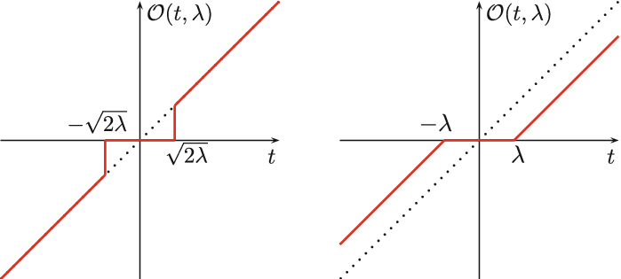

# Exercise

- Using coordinate decent to solve the lasso problem with $p$ variables.
- You may need the soft thresholding operator to derive updating rule.
- Apply to prostate cancer data using svi as outcome variable; compare the result with lars package.

# Constrained optimization - Lagrange multiplier

- Consider ridge regression problem
  - $y \in \mathbb{R}^n$
  - $\beta \in \mathbb{R}^p$
  - $X \in \mathbb{R}^{n \times p}$
  - $f(\beta) = \|y - X\beta\|_2^2$
  - $\arg \min_x \|y - X\beta\|_2^2$ such that $\|\beta\|_2^2 = t$
- Write the Lagrange function using Lagrange multiplier method:
  $$L(\beta) = \|y - X\beta\|_2^2 + \lambda (\|\beta\|_2^2 - t)$$
- Set $\frac{\partial L(\beta)}{\partial \theta} = 0$
  $$X^\top(X\beta - y) + \lambda\beta = 0$$
  $$\beta(\lambda) = (X^\top X + \lambda I)^{-1} X^\top y$$
- solution:
  - $\|\beta(\lambda)\|^2_2 = t$, solve for $\lambda$ (via binary search), then solve for $\beta$

# Constrained optimization - Karush-Kuhn-Tucher conditions

Given general problem

- $\min f(x)$ subject to
  - $h_i(x) \le 0$, $i = 1, 2, \ldots, m$
  - $l_j(x) = 0$, $j = 1, 2, \ldots, r$
- Lagrange function:

$$L(x) = f(x) + \sum_{i=1}^m u_i h_i(x) + \sum_{j=1}^r v_j l_j(x)$$

The **Karush-Kuhn-Tucher conditions** or **KKT conditions** are:

- stationary:
  $$0 = \frac{\partial f(x)}{\partial x} + \sum_{i=1}^m u_i \frac{\partial h_i(x)}{\partial x} + \sum_{j=1}^r v_j \frac{\partial l_j(x)}{\partial x}$$
- complementary slackness:
  $$u_i h_i(x) =0, \forall i$$
- primal feasibility:
  $$h_i(x) \le 0, l_j(x) = 0, \forall i,j$$
- dual feasibility:
  $$u_i \ge 0, \forall i$$

# Application: water-filling (B & V page 245)

- Consider the following problem
  - $\min_{x\in R^n} - \sum_{i=1}^n \log(\alpha_i + x_i)$
  - subject to $x \ge 0$, $1^\top x = 1$
- write down Lagrange function
  $$L(x) = - \sum_{i=1}^n \log(\alpha_i + x_i) - u_i x_i + v(1^\top x - 1)$$
- Applying KKT condition and get
  - $-\frac{1}{\alpha_i + x_i} - u_i + v = 0$, for $i = 1, \ldots, n$
  - $u_i x_i = 0$, for $i = 1, \ldots, n$
  - $x \ge 0$
  - $1^\top x = 1$
  - $u_i \ge 0$, for $i = 1, \ldots, n$

# Application: water-filling (B & V page 245)

- Eliminate $u$:
  - $\frac{1}{\alpha_i + x_i} \le v$, $i = 1, \ldots, n$
  - $x_i (v - \frac{1}{\alpha_i + x_i}) = 0$, $i = 1, \ldots, n$
- Therefore either
  - $x_i = \frac{1}{v} - \alpha_i$, if $v < \frac{1}{\alpha_i}$
  - $x_i = 0$, if $v \ge \frac{1}{\alpha_i}$
- $x = \max \{0, 1/v - \alpha_i \}$
- We need $x$ to be feasible, $1^\top x = 1$, so
  $$\sum_{i=1}^n \max\{0, 1/v - \alpha_i\} = 1$$
  Which is univariate equation. Can solve $v$ using binary search.

# Optimize this function in R

- use function constrOptim
- Fix $n = 10$
- generate $\alpha_i$ from UNIF distribution
- Inequality constraint: $x_i \ge 0$
- Equality constraint: $\sum_i x_i = 1$
  - $\sum_i x_i - 1 \ge 0$
  - $\sum_i x_i - 1 \le 0$
- Constraints:
  - $I x - 0 \ge 0$
  - $1^\top x - 1 \ge 0$
  - $- 1^\top x + 1 \ge 0$

# Optimize this function in R

```r
n <- 10
alpha <- runif(n)
x0 <- runif(n)
x1 <- x0/sum(x0)
f <- function(x){
  -sum(log(alpha + x))
}
grad <- function(x){
  -1/(alpha + x)
}

ui1 <- diag(n)
ui2 <- rep(1,n)
ui3 <- rep(-1,n)
ui <- rbind(ui1, ui2, ui3)

ci1 <- rep(0,n)
ci2 <- 1 - 1e-12
ci3 <- -1 - 1e-12
ci <- c(ci1,ci2,ci3)


constrOptim(x1, f, grad, ui, ci)
```

```
## $par
##  [1] 0.03854230 0.05224637 0.19736554 0.08935701 0.07468487 0.03603157
##  [7] 0.22017346 0.02620023 0.17276648 0.09263218
##
## $value
## [1] 3.937191
##
## $counts
## [1] 0
##
## $convergence
## [1] 0
##
## $message
## NULL
##
## $outer.iterations
## [1] 1
##
## $barrier.value
## [1] 0.0003081647
```

# Exercise

- Solve the water filling problem using KKT condition
- Compare the result with the result from constrOptim function

# Reference

- convex optimization http://www.stat.cmu.edu/~ryantibs/convexopt-S15/
- B & V https://web.stanford.edu/~boyd/cvxbook/bv_cvxbook.pdf

```r
knitr::purl("multiOptimization.rmd", output = "multiOptimization.R ", documentation = 2)
```

```
##
##
## processing file: multiOptimization.rmd
```

[output not shown]

```
## output file: multiOptimization.R
```

```
## [1] "multiOptimization.R "
```